# Code for Bayesian Hierarchical Spatial Modeling of New York City ZIP Code-Level Positive COVID19 Testing Results

Charles DiMaggio, PhD, MPH

Bellevue-NYU Department of Surgery  
Division of Trauma and Critical Care

Last update: 04 May, 2020

Abstract

**Introduction**: The population and spatial characteristics of COVID-19 infections are poorly understood.  
**Methods**: We analyzed positive COVID19 testing results counts within ZIP Code Tabulation Areas (ZCTA) with Bayesian hierarchical Poisson spatial models using integrated nested Laplace approximations.  
**Results**: Spatial clustering accounted for approximately 32% of the variation in the data, with hot spots in all five boroughs. Spatial risk did not correspond precisely to population-based rates of positive tests. The strongest univariate association was with the proportion of residents in a ZIP Code Tabulation Area with Chronic Obstructive Pulmonary Disese (COPD). For every one unit increase in a scaled standardized measure of COPD, there was an approximate 8-fold increase in the risk of a positive COVID-19 test in a ZCTA (Incidence Density Ratio = 8.2, 95% Credible Interval 3.7, 18.3). The next strongest association with with the proportion of Black residents, for which there there was a nearly five-fold increase in the risk of a positive COVID19 test. (IDR = 4.8, 95% Cr I 2.4, 9.7). The proportion of residents older than 65, housing density and the proportion of residents with heart disease were each associated with an approximate doubling of risk. In a multivariable model including estimates for age, COPD, heart disease, housing density and black race, the only variables that remained associated with positive COVID-19 testing with a probability greater than chance were the proportion of black residents and older persons.  
**Conclusions**: The population and spatial patterns of COVID-19 infections differ by race, age, physical environment and health status. Areas with large proportions of Black residents are at markedly higher risk that is not explained by characteristics of the environment and pre-existing conditions in the population.

# 1 Load Data and Packages

Testing data were obtained from the New York City Department of Health and Mental Hygeine (NYC DOHMH) releasing COVID19 tests results posted on [GitHub](https://github.com/nychealth/coronavirus-data). A detailed description of data creation can be found below. Covariate are drawn primarily from 2010 US Census results.

Prep the data by ordering to match the spatial dataframe, and add a sequential area ID variable for the model statements.

```r
library(maptools, quietly = T)
library(sp)
library(spdep, quietly = T)
library(INLA, quietly = T)
library(ggplot2)
library(kableExtra)

library(DescTools)
options(scipen = 10) # don't use scientific notation
options(fmt.num=structure(list(digits=2, big.mark=","), class="fmt")) # force use commas as thousands separator and 2 decimal places



testDat<-readRDS("~/testDat.RDS")
nyc <- readRDS("~/nycMap4COVID.RDS")

nycDat <- attr(nyc, "data")
order <- match(nycDat$ZCTA5CE10,testDat$zcta)
testDat<- testDat[order,]
testDat$ID.area<-seq(1,nrow(testDat))

nyc.adj <- paste("~/nyc.graph")
```

## 1.1 Descriptive Statistics

There were 177 ZCTA’s in the data set. The mean COVID-19 test rate per 10,000 ZCTA population was 166.2 (95% CI 156.7, 175.7). The distribution appeared multimodal. The mean COVID-19 test rate per 10,000 tests was 5,176.0 (95% CI 5,045.9, 5,306.1) and appeared skewed. The The 5 ZCTAs with highest positive COVID-19 test numbers per 10,000 population were the same as those with the highest proportion per 10,000 tests (10464, 10470, 10455, 10473, 11234, and 11210). The 5 lowest ZCTAs were also the same for both measures 1(1103, 11102, 11693, 11369, 11363, and 10308). Table one presents comparative statistics for the ZCTA’s with the highest and lowest quantiles for population-based positive test rates.

```
## -------------------------------------------------------------------------
## Positive COVID-19 Tests per 10,000 ZCTA Population
##
##      length         n        NAs     unique         0s       mean
##         177       177          0        = n          0  166.18312
##                100.0%       0.0%                  0.0%
##
##         .05       .10        .25     median        .75        .90
##    71.10536  84.17626  113.19039  162.97451  215.08084  248.76561
##
##       range        sd      vcoef        mad        IQR       skew
##   281.17539  64.25910    0.38668   75.00825  101.89045    0.18618
##
##      meanCI
##   156.65093
##   175.71531
##
##         .95
##   267.41561
##
##        kurt
##    -0.81984
##
## lowest : 42.02216, 49.81734, 50.22831, 60.10303, 61.66783
## highest: 282.27373, 297.51712, 316.63043, 322.37247, 323.19755
```

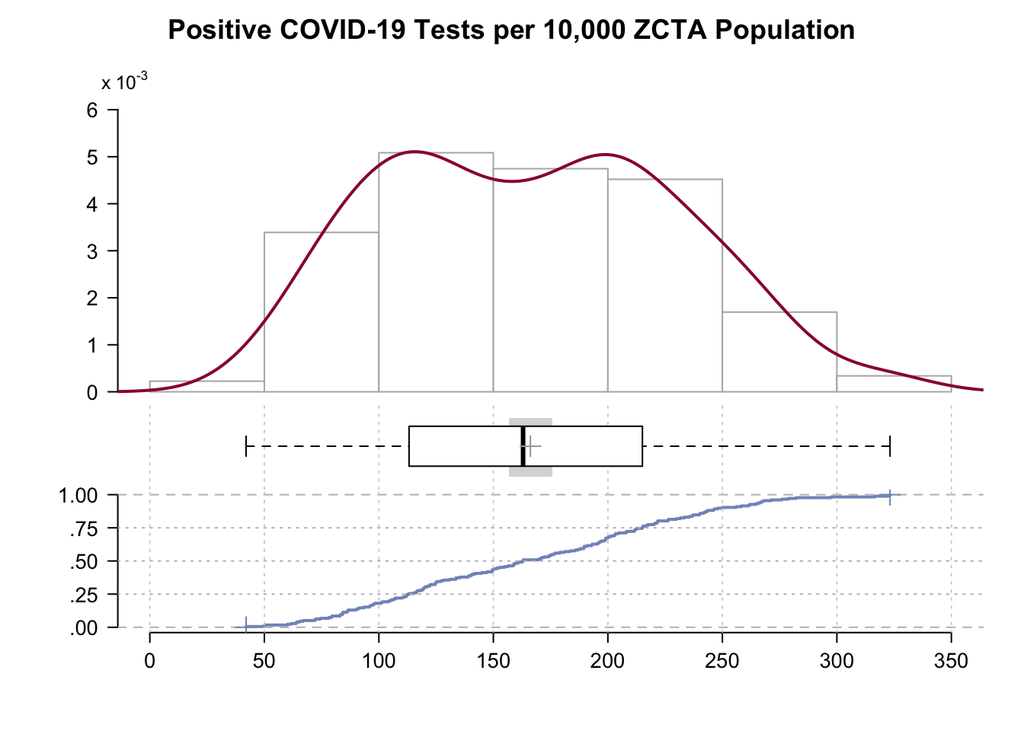

```
## -------------------------------------------------------------------------
## Positive COVID-19 Tests per 10,000 ZCTA Tests
##
##      length          n        NAs     unique         0s       mean
##         177        177          0        = n          0  5'175.967
##                 100.0%       0.0%                  0.0%
##
##         .05        .10        .25     median        .75        .90
##   3'608.459  3'907.126  4'519.016  5'380.117  5'852.102  6'039.269
##
##       range         sd      vcoef        mad        IQR       skew
##   4'747.624    876.960      0.169    780.456  1'333.086     -0.589
##
##      meanCI
##   5'045.879
##   5'306.055
##
##         .95
##   6'198.431
##
##        kurt
##      -0.128
##
## lowest : 2'586.207, 2'937.063, 2'972.973, 3'142.857, 3'178.295
## highest: 6'481.481, 6'614.493, 6'818.530, 6'982.703, 7'333.831
```

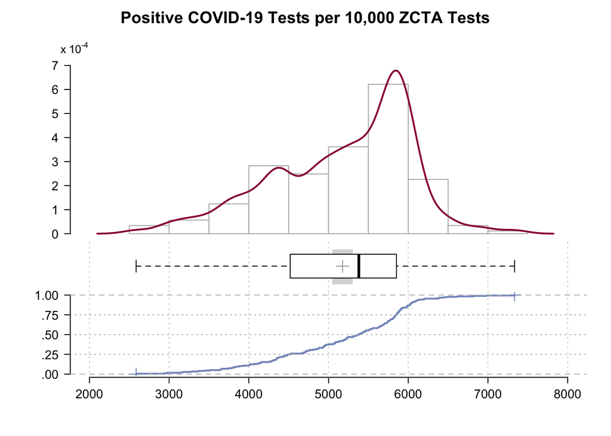

```
## [1] 10464 10470 10455 10473 11234 11210
```

```
## [1] 11103 11102 11693 11369 11363 10308
```

```
## [1] 10464 10470 10455 10473 11234 11210
```

```
## [1] 11103 11102 11693 11369 11363 10308
```

```
##                   var                   total                    High
## 1                   n                      72              36 (50.0%)
## 2                 MHI 57'758.653 (24'986.680) 55'314.528 (19'700.606)
## 3      School Density           5.167 (4.605)           2.658 (1.977)
## 4  Population Density 16'584.935 (11'770.940)   9'486.726 (7'238.221)
## 5     Housing Density 18'165.214 (19'748.001)   8'784.774 (6'788.215)
## 6       Congdon Index          -0.089 (1.996)          -1.118 (1.978)
## 7               Black           0.234 (0.263)           0.355 (0.308)
## 8            Hispanic           0.124 (0.045)           0.134 (0.045)
## 9       Heart Disease           0.111 (0.207)           0.174 (0.268)
## 10               COPD           2.011 (1.932)           2.276 (2.482)
##                        Low    V5
## 1               36 (50.0%)
## 2  82'917.333 (27'557.029) *** '
## 3            7.289 (5.379) *** '
## 4  26'000.104 (13'418.550) *** '
## 5  37'361.654 (33'665.045) *** '
## 6            1.603 (1.942) *** '
## 7            0.069 (0.125) *** '
## 8            0.120 (0.051)     '
## 9            0.072 (0.160)     '
## 10           1.554 (1.420)     '
```

## 1.2 Estimates of Spatial Risk

### 1.2.1 Rate Map

We start with a simple model of postive COVID-19 tests per 10,000 ZCTA population.

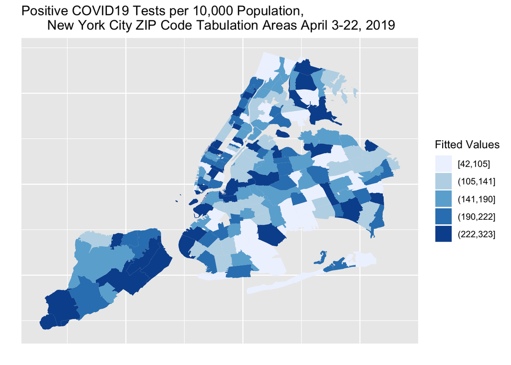

```r
cut.rate<-quantile(testDat$rate,probs = seq(0, 1, by = 0.20))
testDat$rate.cut<-cut(testDat$rate,breaks=cut.rate,include.lowest=TRUE)
# summary(testDat$rate.cut)

nyc.df <- fortify(nyc, region='ZCTA5CE10')
nyc.df <- merge(nyc.df, testDat, by.x="id", by.y="zcta", all=FALSE)
nyc.df <- nyc.df[order(nyc.df$group, nyc.df$order), ]

p1<-ggplot(nyc.df, aes(x=long, y=lat))
p2<-p1+geom_polygon(aes(group=group, fill=rate.cut))
p3<- p2 + scale_fill_brewer(palette="Blues", name="Fitted Values")
map3<- p3+ theme(axis.text.x = element_blank(), axis.text.y = element_blank(),
axis.ticks = element_blank()) +
theme(panel.background = element_rect(colour = NA)) +
xlab("")+ylab("")+
ggtitle("Positive COVID19 Tests per 10,000 Population,
       New York City ZIP Code Tabulation Areas April 3-22, 2019")
print(map3)
```

### 1.2.2 Proportion Map

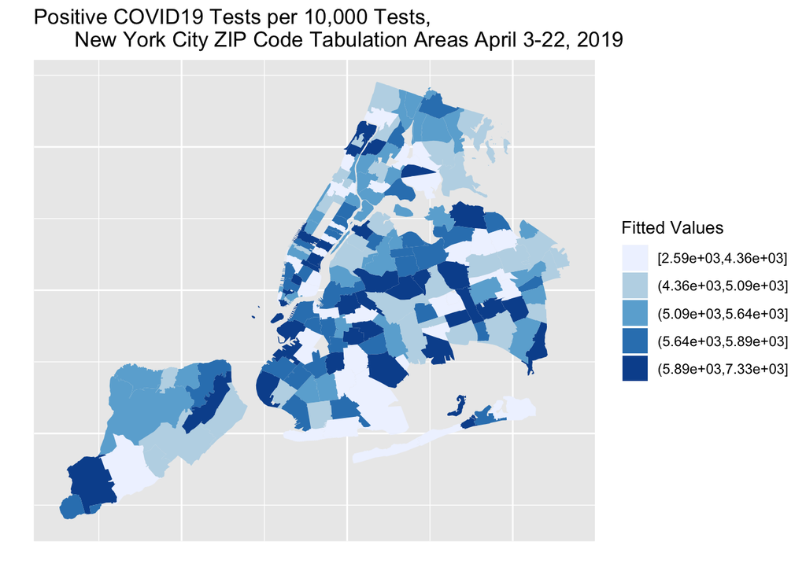

```r
cut.prop<-quantile(testDat$prop,probs = seq(0, 1, by = 0.20))
testDat$prop.cut<-cut(testDat$prop,breaks=cut.prop,include.lowest=TRUE)
# summary(testDat$prop.cut)

nyc.df <- fortify(nyc, region='ZCTA5CE10')
nyc.df <- merge(nyc.df, testDat, by.x="id", by.y="zcta", all=FALSE)
nyc.df <- nyc.df[order(nyc.df$group, nyc.df$order), ]

p1<-ggplot(nyc.df, aes(x=long, y=lat))
p2<-p1+geom_polygon(aes(group=group, fill=prop.cut))
p3<- p2 + scale_fill_brewer(palette="Blues", name="Fitted Values")
map4<- p3+ theme(axis.text.x = element_blank(), axis.text.y = element_blank(),
axis.ticks = element_blank()) +
theme(panel.background = element_rect(colour = NA)) +
xlab("")+ylab("")+
ggtitle("Positive COVID19 Tests per 10,000 Tests,
       New York City ZIP Code Tabulation Areas April 3-22, 2019")
print(map4)
```

# 2 Unstructured Heterogenity (Frailty) Model

As a baseline against which to measure more informative models, run a simple random effects (spatially unstructured heterogeneity) model of the total number of positive tests in a ZIP Code Tabulation Area with the total number of tests performed as an offset variable [^1].

$y_i = \alpha + \upsilon_i$

The following code sets up, runs the model and reviews the results.

```r
formulaUH <- Positive~ f(ID.area, model = "iid", offset(Total)) # specify model
resultUH <- inla(formulaUH,family="poisson", data=testDat, control.compute=list(dic=TRUE,cpo=TRUE))

summary(resultUH)
```

```
##
## Call:
## c("inla(formula = formulaUH, family = \"poisson\", data = testDat, ",  "    control.compute = list(dic = TRUE, cpo = TRUE))")
##
## Time used:
##  Pre-processing    Running inla Post-processing           Total
##          0.7359          0.2593          0.2731          1.2682
##
## Fixed effects:
##               mean     sd 0.025quant 0.5quant 0.975quant   mode kld
## (Intercept) 4.1734 0.0786     4.0167   4.1742     4.3256 4.1758   0
##
## Random effects:
## Name   Model
##  ID.area   IID model
##
## Model hyperparameters:
##                       mean      sd        0.025quant 0.5quant  0.975quant
## Precision for ID.area 214039.80  25751.73 167309.23  212751.27 268376.81
##                       mode
## Precision for ID.area 210420.59
##
## Expected number of effective parameters(std dev): 174.43(0.1474)
## Number of equivalent replicates : 1.015
##
## Deviance Information Criterion: 1831.58
## Effective number of parameters: 174.50
##
## Marginal Likelihood:  -1547.62
## CPO and PIT are computed
##
## Posterior marginals for linear predictor and fitted values computed
```

```r
exp(resultUH$summary.fixed)
```

```
##                 mean       sd 0.025quant 0.5quant 0.975quant     mode kld
## (Intercept) 64.93475 1.081825   55.51482 64.98622   75.61373 65.09194   1
```

```r
mean(testDat$Positive, na.rm=T) # model results differ because adjusted for population
```

```
## [1] 772.9209
```

This first model illustrates the random effect term, with no explicit spatial component. The deviance information criteria for this model is 1831.58, with 174.5 effective parameters. The fixed effects for this model consists only of the intercept, which exponentiates to a mean [^2] of 64.9 positive tests per ZCTA (sd= 1.1, 95% Credible Interval 55.5 , 75.6) and a mode [^3] of 65.1

The variance results are stored in the “region” part of “summary.random” in the named list object created from the INLA run. We extract and examine the mean random effect term for each county. Recall, this is the *random variation, on the log scale, around the mean or intercept value of the number of positive test in a NYC ZCTA* with an offset term for the total ZCTA population.

The line graph plots the density of the random effect term around the mean value restricted on some of the negative values to better illustrated the (approximately) normal distribution of the random effects.

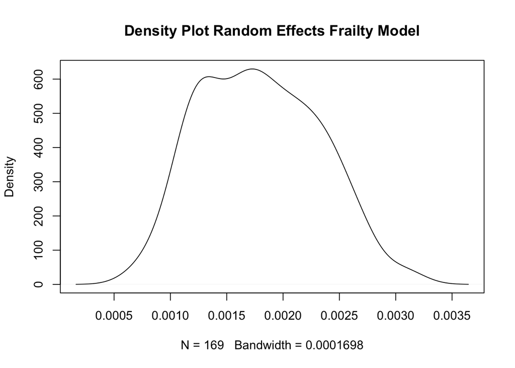

```r
re1<-resultUH$summary.random$ID.area[,2]
# plot(density(re1)) # plot density random effects

plot(density(re1[re1>-2e-04]), main="Density Plot Random Effects Frailty Model") # restrict
```

We next map the random effects term to illustrate the distribution of the unstructured heterogeneity or variance. The results (as expected) appear generally as a spatially random distribution of variance above and below the mean value.

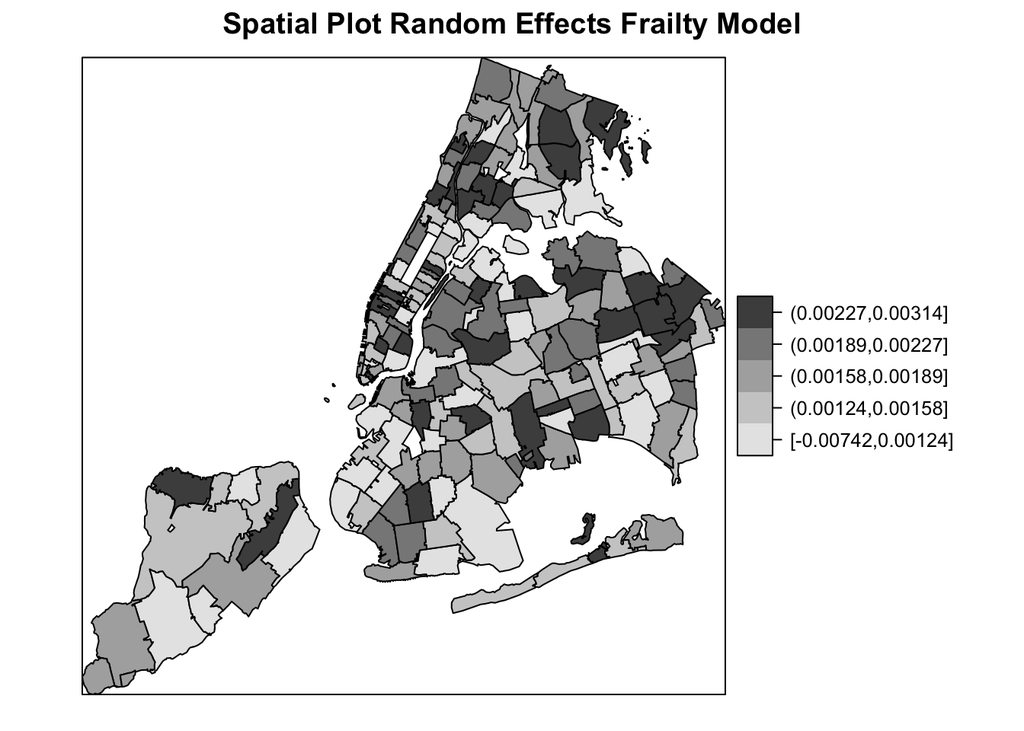

```r
# add random effects results to dataframe
testDat$UH<-re1

# create cuts
cuts <-quantile(testDat$UH,probs = seq(0, 1, by = 0.20))
testDat$UH.cut<-cut(testDat$UH,breaks=cuts,include.lowest=TRUE)

#merge dataframes, save to data slot of map
testDat$ZCTA5CE10<-testDat$zcta
attr(nyc,"data") <- merge(nycDat,testDat,by="ZCTA5CE10")

# map
spplot(nyc, "UH.cut", col.regions= rev(grey.colors(5)),main="Spatial Plot Random Effects Frailty Model")
```

The following image recreates the plot with `ggplot`.

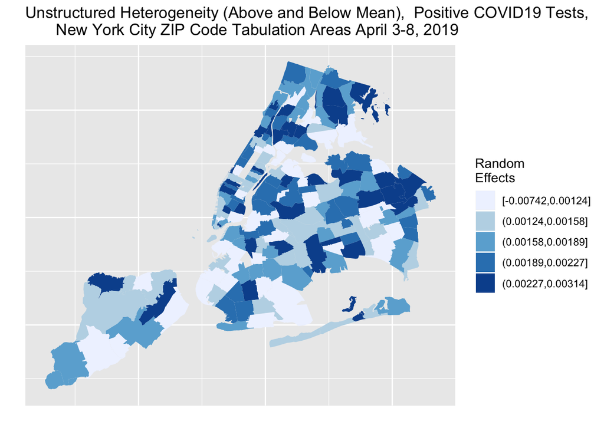

```r
nyc.df <- fortify(nyc, region='ZCTA5CE10')
nyc.df <- merge(nyc.df, testDat, by.x="id", by.y="zcta", all=FALSE)
nyc.df <- nyc.df[order(nyc.df$group, nyc.df$order), ]

library(RColorBrewer)
p1<-ggplot(nyc.df, aes(x=long, y=lat))
p2<-p1+geom_polygon(aes(group=group, fill=UH.cut))
p3<- p2 + scale_fill_brewer(palette="Blues", name="Random\nEffects")
map1<- p3+ theme(axis.text.x = element_blank(), axis.text.y = element_blank(),
axis.ticks = element_blank()) +
theme(panel.background = element_rect(colour = NA)) +
xlab("")+ylab("")+
ggtitle("Unstructured Heterogeneity (Above and Below Mean),  Positive COVID19 Tests,
       New York City ZIP Code Tabulation Areas April 3-8, 2019")
print(map1)
```

# 3 Spatially Structured (Convolution) Model

The convolution models add a spatially-structured conditional autoregression term ($\nu$) to the spatially-unstructured heterogeneity random effect term ($\upsilon$) of the frailty model.

$$y_i = \alpha + \upsilon_i + \nu_i$$

The model statement now specifies a Besag-York-Mollie model, and references a spatial neighbor adjacency matrix which allows for connected components [^4].

The DIC of 1807.60 (with 175.98 effective parameters) is an improvment over the baseline unstructured heterogeneity frailty model, indicating the spatial component is adding information to the simple unstructured model.

the mean count of positive tests within a ZCTA has increased to 76.5 (95% Cr I 56.5, 103.0), indicating that some of the information in the model has shifted from unstructured or random variance to structured spatial variance. The incidence density of the unstructured heterogeneity appears similar to the frailty model. The density plot of the spatial heterogeneity is similarly normally bunced around the mean.

```r
formulaCAR <- Positive~ f(ID.area, model="bym", offset(Total), graph=nyc.adj, adjust.for.con.comp = FALSE)
resultCAR <- inla(formulaCAR,family="poisson", data=testDat, control.compute=list(dic=TRUE,cpo=TRUE))

summary(resultCAR)
```

```
##
## Call:
## c("inla(formula = formulaCAR, family = \"poisson\", data = testDat, ",  "    control.compute = list(dic = TRUE, cpo = TRUE))")
##
## Time used:
##  Pre-processing    Running inla Post-processing           Total
##          1.4306          0.6584          0.9391          3.0281
##
## Fixed effects:
##               mean     sd 0.025quant 0.5quant 0.975quant   mode kld
## (Intercept) 4.3379 0.1529     4.0338   4.3392     4.6348 4.3418   0
##
## Random effects:
## Name   Model
##  ID.area   BYM model
##
## Model hyperparameters:
##                                           mean     sd       0.025quant
## Precision for ID.area (iid component)     78563.94 10034.25 60460.59
## Precision for ID.area (spatial component) 49807.85  8164.09 35555.22
##                                           0.5quant 0.975quant mode
## Precision for ID.area (iid component)     78027.34 99834.11   77051.76
## Precision for ID.area (spatial component) 49206.19 67569.48   48068.37
##
## Expected number of effective parameters(std dev): 175.98(0.0778)
## Number of equivalent replicates : 1.006
##
## Deviance Information Criterion: 1807.60
## Effective number of parameters: 175.98
##
## Marginal Likelihood:  -1606.26
## CPO and PIT are computed
##
## Posterior marginals for linear predictor and fitted values computed
```

```r
exp(resultCAR$summary.fixed)
```

```
##                 mean       sd 0.025quant 0.5quant 0.975quant     mode kld
## (Intercept) 76.54614 1.165231   56.47445   76.644   103.0036 76.84784   1
```

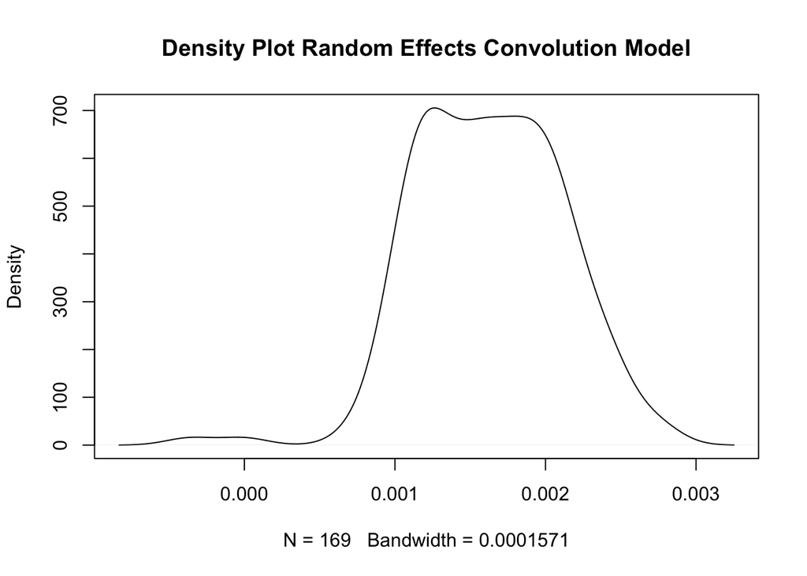

```r
re<-resultCAR$summary.random$ID.area[1:length(testDat$zcta),2]
plot(density(re[re>-0.002]), main="Density Plot Random Effects Convolution Model") # plot density random effects
```

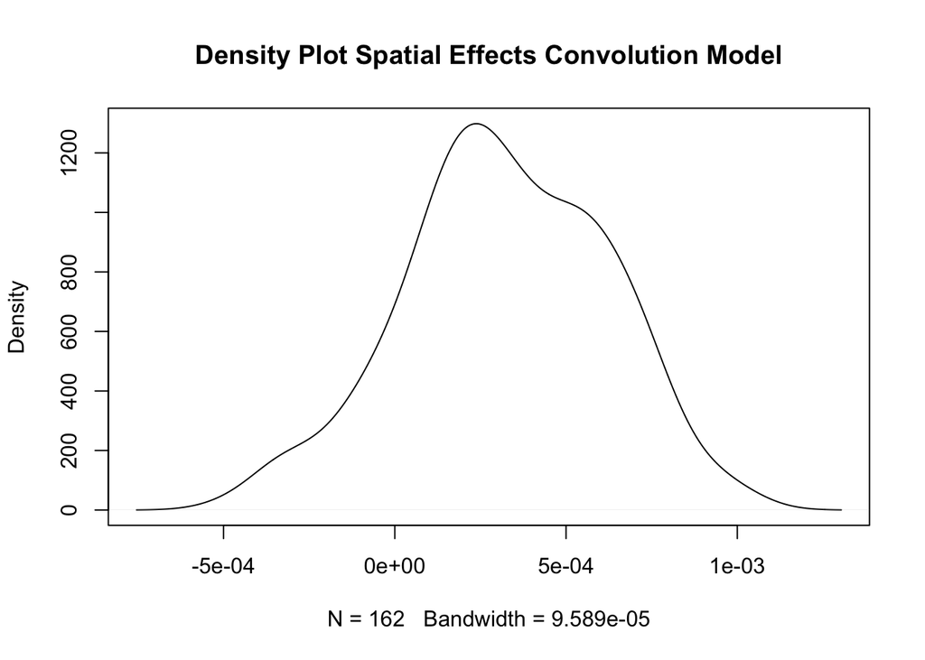

```r
car<-resultCAR$summary.random$ID.area[(length(testDat$zcta)+1):(2*length(testDat$ZCTA)),2]
plot(density(car[car>-0.0005]),main="Density Plot Spatial Effects Convolution Model") # plot density spatial effects
```

We next map the results of the spatial heterogeneity. Again, these are variance values above and below zero, only now they represent spatial variance. To the eye, there appears to be some more structure to the data than in the simple frailty model, with some ZCTAs demonstrating higher variance estimates than others.

```r
# add car results to dataframe
testDat$car<-car

# create cuts
cuts <- quantile(testDat$car,probs = seq(0, 1, by = 0.20))
summary(cuts)
```

```
##       Min.    1st Qu.     Median       Mean    3rd Qu.       Max.
## -8.357e-03  4.581e-05  2.802e-04 -1.036e-03  5.189e-04  1.016e-03
```

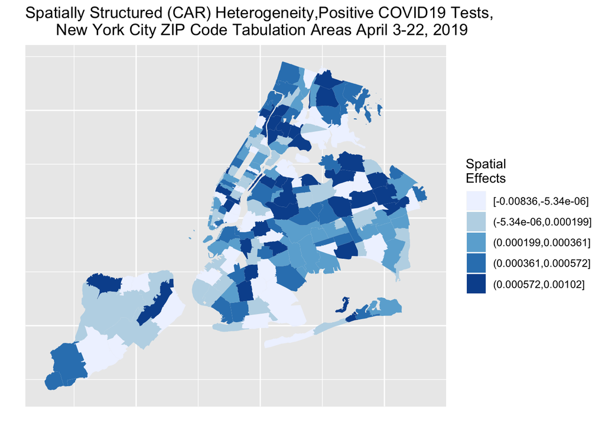

```r
testDat$car.cut<-cut(testDat$car,breaks=cuts, include.lowest=TRUE, include.highest=TRUE)

nyc.df <- fortify(nyc, region='ZCTA5CE10')
nyc.df <- merge(nyc.df, testDat, by.x="id", by.y="zcta", all=FALSE)
nyc.df <- nyc.df[order(nyc.df$group, nyc.df$order), ]

# library(RColorBrewer)
p1<-ggplot(nyc.df, aes(x=long, y=lat))
p2<-p1+geom_polygon(aes(group=group, fill=car.cut))
p3<- p2 + scale_fill_brewer(palette="Blues", name="Spatial\nEffects")
map2<- p3+ theme(axis.text.x = element_blank(), axis.text.y = element_blank(),
axis.ticks = element_blank()) +
theme(panel.background = element_rect(colour = NA)) +
xlab("")+ylab("")+
ggtitle("Spatially Structured (CAR) Heterogeneity,Positive COVID19 Tests,
       New York City ZIP Code Tabulation Areas April 3-22, 2019")
print(map2)
```

### 3.0.1 Map of Fitted Values

Using calcuations [^5] from the fitted convolution model, we first map the so-called fitted variance values, which are the sum of the mean value, plus the unstructured and spatially structured variance components ($\theta = \alpha + \upsilon + \nu$).

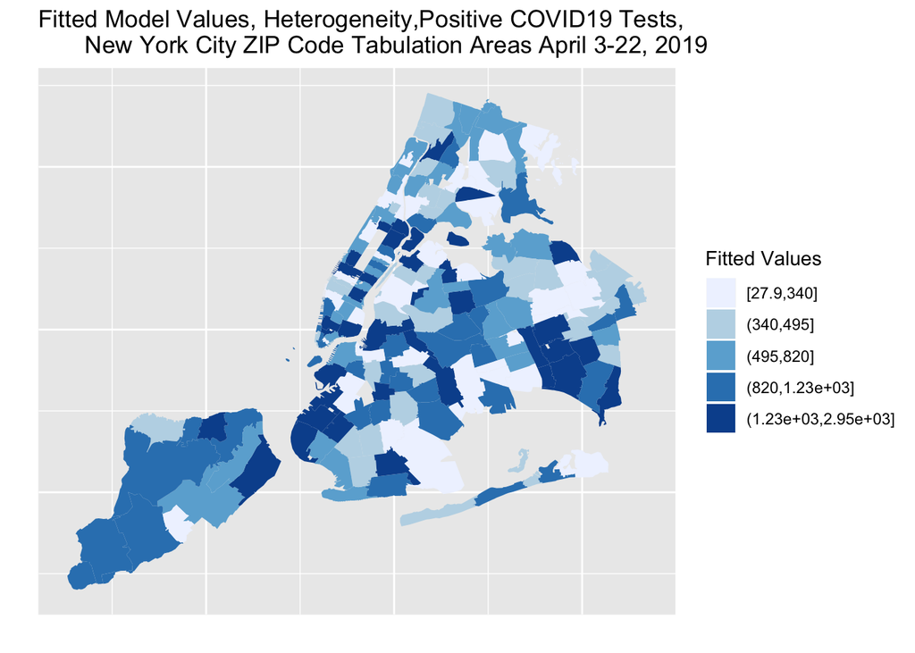

```r
#risk (theta = alpha + upsilon + nu)
CARfit <- resultCAR$summary.fitted.values[,1]

testDat$fit<-CARfit
cut.fit<-quantile(testDat$fit,probs = seq(0, 1, by = 0.20))
testDat$fit.cut<-cut(testDat$fit,breaks=cut.fit,include.lowest=TRUE)
# summary(testDat$fit.cut)

nyc.df <- fortify(nyc, region='ZCTA5CE10')
nyc.df <- merge(nyc.df, testDat, by.x="id", by.y="zcta", all=FALSE)
nyc.df <- nyc.df[order(nyc.df$group, nyc.df$order), ]

p1<-ggplot(nyc.df, aes(x=long, y=lat))
p2<-p1+geom_polygon(aes(group=group, fill=fit.cut))
p3<- p2 + scale_fill_brewer(palette="Blues", name="Fitted Values")
map5<- p3+ theme(axis.text.x = element_blank(), axis.text.y = element_blank(),
axis.ticks = element_blank()) +
theme(panel.background = element_rect(colour = NA)) +
xlab("")+ylab("")+
ggtitle("Fitted Model Values, Heterogeneity,Positive COVID19 Tests,
       New York City ZIP Code Tabulation Areas April 3-22, 2019")
print(map5)
```

### 3.0.2 Map of Spatial Risk Estimate

The spatial risk estimate is calculated as the sum of the unstructured and spatially structured variance components (($\zeta = \upsilon + \nu$))

```r
#spatial risk (zeta = upsilon + nu)
CARmarginals <- resultCAR$marginals.random$ID.area[1:177]
CARzeta <- lapply(CARmarginals,function(x)inla.emarginal(exp,x)) # exponentiate

testDat$risk<-unlist(CARzeta)
cut.risk<-quantile(testDat$risk, probs = seq(0, 1, by = 0.20))
testDat$risk.cut<-cut(testDat$risk,breaks=cut.risk,include.lowest=TRUE)
# summary(testDat$risk.cut)

nyc.df <- fortify(nyc, region='ZCTA5CE10')
nyc.df <- merge(nyc.df, testDat, by.x="id", by.y="zcta", all=FALSE)
nyc.df <- nyc.df[order(nyc.df$group, nyc.df$order), ]

p1<-ggplot(nyc.df, aes(x=long, y=lat))
p2<-p1+geom_polygon(aes(group=group, fill=risk.cut))
p3<- p2 + scale_fill_brewer(palette="Blues", name="Spatial\nRisk")
map6<- p3+ theme(axis.text.x = element_blank(), axis.text.y = element_blank(),
axis.ticks = element_blank()) +
theme(panel.background = element_rect(colour = NA)) +
xlab("")+ylab("")+
ggtitle("Spatially Structured Risk Estimates, Heterogeneity,Positive COVID19 Tests,
       New York City ZIP Code Tabulation Areas April 3-22, 2019")
print(map6)
```

[output not shown]

### 3.0.3 Risk Exceedence Map

Finally, we calculate and map the probability of relative risk greater than 1, is a type of “hot spot” map.

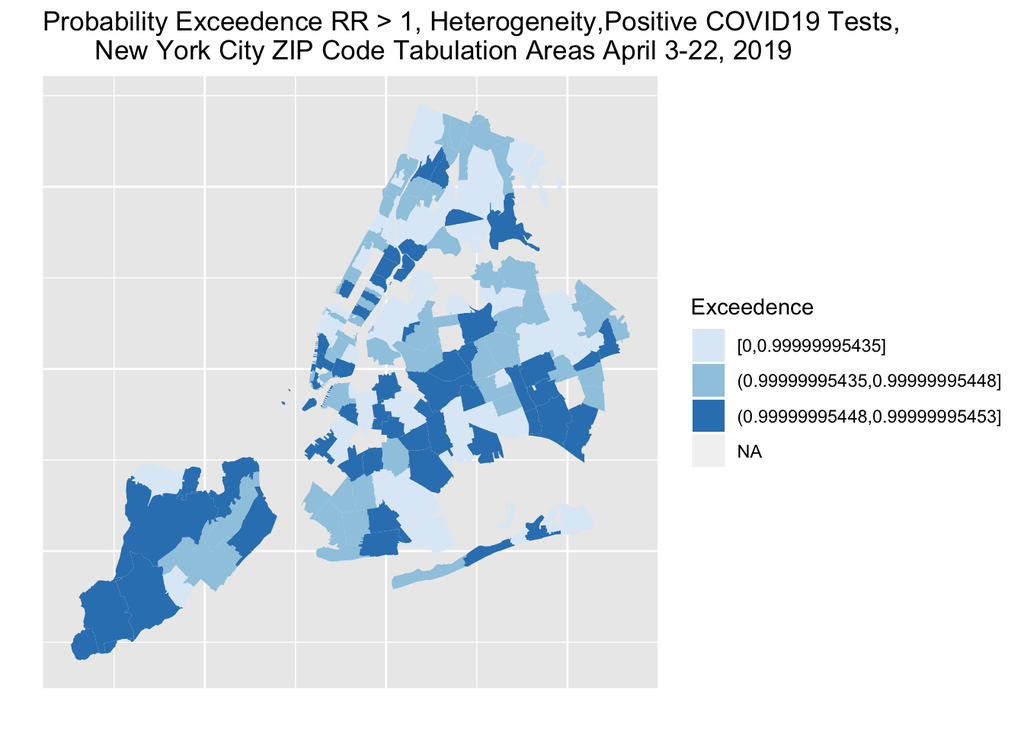

```r
# exceedence probability
a=0
CARexceed<-lapply(resultCAR$marginals.random$ID.area[1:177], function(X){
  1-inla.pmarginal(a, X)
})

testDat$exceed<-unlist(CARexceed)
cut.exceed<-quantile(testDat$exceed,probs = seq(0, 1, by = 0.30))
testDat$exceed.cut<-cut(testDat$exceed, breaks=cut.exceed, include.lowest=TRUE)
# summary(testDat$exceed.cut)
# testDat$exceed

nyc.df <- fortify(nyc, region='ZCTA5CE10')
nyc.df <- merge(nyc.df, testDat, by.x="id", by.y="zcta", all=FALSE)
nyc.df <- nyc.df[order(nyc.df$group, nyc.df$order), ]


p1<-ggplot(nyc.df, aes(x=long, y=lat))
p2<-p1+geom_polygon(aes(group=group, fill=exceed.cut))
p3<- p2 + scale_fill_brewer(palette="Blues", name="Exceedence")
map7<- p3+ theme(axis.text.x = element_blank(), axis.text.y = element_blank(),
axis.ticks = element_blank()) +
theme(panel.background = element_rect(colour = NA)) +
xlab("")+ylab("")+
ggtitle("Probability Exceedence RR > 1, Heterogeneity,Positive COVID19 Tests,
       New York City ZIP Code Tabulation Areas April 3-22, 2019")
print(map7)
```

Finally, we estimate the proportion of the variance explained [^6] by geographic variation or place, which for this model is approximately 32%

```r
mat.marg <- matrix(NA, nrow=177, ncol=1000)
m<-resultCAR$marginals.random$ID.area
for (i in 1:177){
  u<-m[[177+i]]
  s<-inla.rmarginal(1000, u)
  mat.marg[i,]<-s}
var.RRspatial<-mean(apply(mat.marg, 2, sd))^2
var.RRhet<-inla.emarginal(function(x) 1/x,
        resultCAR$marginals.hyper$"Precision for ID.area (iid component)")
var.RRspatial/(var.RRspatial+var.RRhet)  # 0.3200823
```

```
## [1] 0.3204903
```

# 4 Single Covariate Models

While important, place alone does not account for the majority of the variation in the data. We explore to see if there are other factors that can more fully explain the variation. In the following sections we look at population density, median household income, school density, housing density, and a measure of social disorder called the Congdon Index.

## 4.1 Population Density

```r
formulaCOV1 <- Positive~ f(ID.area, model="bym", offset(Total), graph=nyc.adj, adjust.for.con.comp = FALSE)+ scale(POPDEN2010)
resultCOV1 <- inla(formulaCOV1,family="poisson",data=testDat, control.compute=list(dic=TRUE,cpo=TRUE))

summary(resultCOV1)
```

```
##
## Call:
## c("inla(formula = formulaCOV1, family = \"poisson\", data = testDat, ",  "    control.compute = list(dic = TRUE, cpo = TRUE))")
##
## Time used:
##  Pre-processing    Running inla Post-processing           Total
##          0.1644          0.7708          0.0327          0.9680
##
## Fixed effects:
##                     mean     sd 0.025quant 0.5quant 0.975quant   mode kld
## (Intercept)       4.4556 0.1592     4.1394   4.4567     4.7652 4.4592   0
## scale(POPDEN2010) 0.4164 0.1789     0.0661   0.4159     0.7687 0.4150   0
##
## Random effects:
## Name   Model
##  ID.area   BYM model
##
## Model hyperparameters:
##                                           mean      sd        0.025quant
## Precision for ID.area (iid component)      81441.14  10410.38  62456.43
## Precision for ID.area (spatial component)  48642.69   7979.13  34706.10
##                                           0.5quant  0.975quant mode
## Precision for ID.area (iid component)      80985.37 103232.31   80259.74
## Precision for ID.area (spatial component)  48057.71  65992.86   46954.25
##
## Expected number of effective parameters(std dev): 176.09(0.0698)
## Number of equivalent replicates : 1.005
##
## Deviance Information Criterion: 1805.89
## Effective number of parameters: 176.08
##
## Marginal Likelihood:  -1608.73
## CPO and PIT are computed
##
## Posterior marginals for linear predictor and fitted values computed
```

```r
# resultCOV1$dic

exp(resultCOV1$summary.fixed)
```

```
##                        mean       sd 0.025quant  0.5quant 0.975quant
## (Intercept)       86.105746 1.172605  62.764857 86.205575 117.350329
## scale(POPDEN2010)  1.516417 1.195876   1.068316  1.515743   2.156968
##                        mode kld
## (Intercept)       86.414637   1
## scale(POPDEN2010)  1.514399   1
```

## 4.2 Median Household Income

By contrast, for each unit increase in a standardized measure of median household income in a ZIP Code Tabulation Area, there is a an approximately 46% *decrease* in the number of positive COVID19 tests. (Incidence Density Ratio = 0.54, 95% CrI 0.43, 0.69). This model had a slightly improved DIC, at 1803.51.

```r
formulaCOV2 <- Positive~ f(ID.area, model="bym", offset(Total), graph=nyc.adj, adjust.for.con.comp = FALSE)+ scale(MHI)
resultCOV2 <- inla(formulaCOV2,family="poisson",data=testDat, control.compute=list(dic=TRUE,cpo=TRUE))

summary(resultCOV2)
```

```
##
## Call:
## c("inla(formula = formulaCOV2, family = \"poisson\", data = testDat, ",  "    control.compute = list(dic = TRUE, cpo = TRUE))")
##
## Time used:
##  Pre-processing    Running inla Post-processing           Total
##          0.1160          0.6455          0.0420          0.8035
##
## Fixed effects:
##                mean     sd 0.025quant 0.5quant 0.975quant    mode kld
## (Intercept)  5.0191 0.1917     4.6399   5.0199     5.3936  5.0215   0
## scale(MHI)  -0.6119 0.1194    -0.8473  -0.6117    -0.3781 -0.6112   0
##
## Random effects:
## Name   Model
##  ID.area   BYM model
##
## Model hyperparameters:
##                                           mean      sd        0.025quant
## Precision for ID.area (iid component)      89559.50  11265.11  69221.85
## Precision for ID.area (spatial component)  53825.38   8606.83  38843.93
##                                           0.5quant  0.975quant mode
## Precision for ID.area (iid component)      88959.01 113435.35   87860.53
## Precision for ID.area (spatial component)  53170.83  72595.67   51904.56
##
## Expected number of effective parameters(std dev): 175.93(0.0805)
## Number of equivalent replicates : 1.006
##
## Deviance Information Criterion: 1803.51
## Effective number of parameters: 175.90
##
## Marginal Likelihood:  -1599.16
## CPO and PIT are computed
##
## Posterior marginals for linear predictor and fitted values computed
```

```r
# resultCOV1$dic

exp(resultCOV2$summary.fixed)
```

```
##                    mean       sd  0.025quant   0.5quant  0.975quant
## (Intercept) 151.2791564 1.211339 103.5375077 151.397811 219.9958200
## scale(MHI)    0.5422973 1.126800   0.4285869   0.542424   0.6851286
##                    mode kld
## (Intercept) 151.6386961   1
## scale(MHI)    0.5426838   1
```

## 4.3 School Density

The density of schools in a ZIP Code Tabulation Area does not appear to be associated with risk of positive COVID19 tests.

```r
formulaCOV3 <- Positive~ f(ID.area, model="bym", offset(Total), graph=nyc.adj, adjust.for.con.comp = FALSE)+ scale(schDen)
resultCOV3 <- inla(formulaCOV3,family="poisson",data=testDat, control.compute=list(dic=TRUE,cpo=TRUE))

summary(resultCOV3)
```

```
##
## Call:
## c("inla(formula = formulaCOV3, family = \"poisson\", data = testDat, ",  "    control.compute = list(dic = TRUE, cpo = TRUE))")
##
## Time used:
##  Pre-processing    Running inla Post-processing           Total
##          0.1115          0.7999          0.0318          0.9432
##
## Fixed effects:
##                  mean     sd 0.025quant 0.5quant 0.975quant    mode kld
## (Intercept)    4.3285 0.1536      4.023   4.3298     4.6266  4.3325   0
## scale(schDen) -0.1731 0.1713     -0.511  -0.1727     0.1621 -0.1718   0
##
## Random effects:
## Name   Model
##  ID.area   BYM model
##
## Model hyperparameters:
##                                           mean     sd       0.025quant
## Precision for ID.area (iid component)     78425.13 10012.90 60088.02
## Precision for ID.area (spatial component) 49497.02  8134.05 35268.88
##                                           0.5quant 0.975quant mode
## Precision for ID.area (iid component)     78013.35 99340.81   77391.14
## Precision for ID.area (spatial component) 48910.27 67154.77   47812.06
##
## Expected number of effective parameters(std dev): 176.09(0.0703)
## Number of equivalent replicates : 1.005
##
## Deviance Information Criterion: 1806.91
## Effective number of parameters: 176.09
##
## Marginal Likelihood:  -1610.97
## CPO and PIT are computed
##
## Posterior marginals for linear predictor and fitted values computed
```

```r
# resultCOV1$dic

exp(resultCOV3$summary.fixed)
```

```
##                     mean       sd 0.025quant  0.5quant 0.975quant
## (Intercept)   75.8290784 1.166004 55.8665076 75.928513 102.163694
## scale(schDen)  0.8410627 1.186810  0.5999054  0.841428   1.175933
##                     mode kld
## (Intercept)   76.1351561   1
## scale(schDen)  0.8421715   1
```

## 4.4 Population Older Than 65

The proportion of a population older than 65 nearly doubles the risk of higher positive COVID19 testing counts. (IDR = 1.9, 95% CrI 1.6, 2.4), The DIC for this model (1800.70) was better than that for population density or median household income.

```r
formulaCOV4 <- Positive~ f(ID.area, model="bym", offset(Total), graph=nyc.adj, adjust.for.con.comp = FALSE)+ scale(propOld)
resultCOV4 <- inla(formulaCOV4,family="poisson",data=testDat, control.compute=list(dic=TRUE,cpo=TRUE))

summary(resultCOV4)
```

```
##
## Call:
## c("inla(formula = formulaCOV4, family = \"poisson\", data = testDat, ",  "    control.compute = list(dic = TRUE, cpo = TRUE))")
##
## Time used:
##  Pre-processing    Running inla Post-processing           Total
##          0.1119          0.6099          0.0328          0.7545
##
## Fixed effects:
##                  mean     sd 0.025quant 0.5quant 0.975quant   mode kld
## (Intercept)    4.9971 0.1742     4.6525   4.9978     5.3373 4.9993   0
## scale(propOld) 0.6556 0.1098     0.4410   0.6552     0.8723 0.6544   0
##
## Random effects:
## Name   Model
##  ID.area   BYM model
##
## Model hyperparameters:
##                                           mean      sd        0.025quant
## Precision for ID.area (iid component)      95113.30  11926.66  73574.50
## Precision for ID.area (spatial component)  53282.13   8415.75  38629.79
##                                           0.5quant  0.975quant mode
## Precision for ID.area (iid component)      94479.78 120384.80   93321.20
## Precision for ID.area (spatial component)  52642.56  71629.27   51399.96
##
## Expected number of effective parameters(std dev): 175.89(0.0846)
## Number of equivalent replicates : 1.006
##
## Deviance Information Criterion: 1800.70
## Effective number of parameters: 175.84
##
## Marginal Likelihood:  -1594.69
## CPO and PIT are computed
##
## Posterior marginals for linear predictor and fitted values computed
```

```r
# resultCOV1$dic

exp(resultCOV4$summary.fixed)
```

```
##                      mean       sd 0.025quant   0.5quant 0.975quant
## (Intercept)    147.983479 1.190321 104.847646 148.091430  207.95868
## scale(propOld)   1.926341 1.116080   1.554211   1.925564    2.39237
##                      mode kld
## (Intercept)    148.312848   1
## scale(propOld)   1.924017   1
```

## 4.5 Asian Population

A larger proportion of persons in a ZCTA who identify as Asian was associated with a lower risk of positive ZCTA tests (IDR=0.43, 95 % CrI 0.23, 0.77), though the DIC of 1806.07 was not as good as previous models.

```r
formulaCOV5 <- Positive~ f(ID.area, model="bym", offset(Total), graph=nyc.adj, adjust.for.con.comp = FALSE)+ scale(propAsian)
resultCOV5 <- inla(formulaCOV5,family="poisson",data=testDat, control.compute=list(dic=TRUE,cpo=TRUE))

summary(resultCOV5)
```

```
##
## Call:
## c("inla(formula = formulaCOV5, family = \"poisson\", data = testDat, ",  "    control.compute = list(dic = TRUE, cpo = TRUE))")
##
## Time used:
##  Pre-processing    Running inla Post-processing           Total
##          0.1134          0.6491          0.0434          0.8059
##
## Fixed effects:
##                     mean     sd 0.025quant 0.5quant 0.975quant    mode kld
## (Intercept)       4.6164 0.1782     4.2630   4.6174     4.9637  4.6195   0
## scale(propAsian) -0.8473 0.3006    -1.4399  -0.8467    -0.2586 -0.8454   0
##
## Random effects:
## Name   Model
##  ID.area   BYM model
##
## Model hyperparameters:
##                                           mean      sd        0.025quant
## Precision for ID.area (iid component)      81808.20  10377.00  62934.41
## Precision for ID.area (spatial component)  50496.98   8201.52  36111.30
##                                           0.5quant  0.975quant mode
## Precision for ID.area (iid component)      81338.78 103544.68   80568.21
## Precision for ID.area (spatial component)  49920.89  68257.31   48849.87
##
## Expected number of effective parameters(std dev): 175.98(0.0778)
## Number of equivalent replicates : 1.006
##
## Deviance Information Criterion: 1806.07
## Effective number of parameters: 175.96
##
## Marginal Likelihood:  -1606.97
## CPO and PIT are computed
##
## Posterior marginals for linear predictor and fitted values computed
```

```r
# resultCOV1$dic

exp(resultCOV5$summary.fixed)
```

```
##                         mean       sd 0.025quant    0.5quant  0.975quant
## (Intercept)      101.1252844 1.195115 71.0259479 101.2294592 143.1201598
## scale(propAsian)   0.4285804 1.350657  0.2369453   0.4288386   0.7721541
##                         mode kld
## (Intercept)      101.4435898   1
## scale(propAsian)   0.4293655   1
```

## 4.6 Housing density

Every one unit increase in a measure of housing density, was associated with a doubling of risk of positive COVID19 testing (IDR=2.0, 95% CrI 1.2, 3.2)

```r
formulaCOV6 <- Positive~ f(ID.area, model="bym", offset(Total), graph=nyc.adj, adjust.for.con.comp = FALSE)+ scale(houseDensity1)
resultCOV6 <- inla(formulaCOV6,family="poisson",data=testDat, control.compute=list(dic=TRUE,cpo=TRUE))

summary(resultCOV6)
```

```
##
## Call:
## c("inla(formula = formulaCOV6, family = \"poisson\", data = testDat, ",  "    control.compute = list(dic = TRUE, cpo = TRUE))")
##
## Time used:
##  Pre-processing    Running inla Post-processing           Total
##          0.1124          0.6280          0.0323          0.7727
##
## Fixed effects:
##                        mean     sd 0.025quant 0.5quant 0.975quant   mode
## (Intercept)          4.5503 0.1693     4.2139   4.5515     4.8796 4.5541
## scale(houseDensity1) 0.6703 0.2552     0.1692   0.6702     1.1719 0.6698
##                      kld
## (Intercept)            0
## scale(houseDensity1)   0
##
## Random effects:
## Name   Model
##  ID.area   BYM model
##
## Model hyperparameters:
##                                           mean      sd        0.025quant
## Precision for ID.area (iid component)      81855.74  10468.71  62953.53
## Precision for ID.area (spatial component)  49927.30   8144.44  35663.53
##                                           0.5quant  0.975quant mode
## Precision for ID.area (iid component)      81303.88 104022.04   80309.16
## Precision for ID.area (spatial component)  49346.23  67591.52   48260.46
##
## Expected number of effective parameters(std dev): 176.05(0.0733)
## Number of equivalent replicates : 1.005
##
## Deviance Information Criterion: 1806.69
## Effective number of parameters: 176.03
##
## Marginal Likelihood:  -1607.65
## CPO and PIT are computed
##
## Posterior marginals for linear predictor and fitted values computed
```

```r
# resultCOV1$dic

exp(resultCOV6$summary.fixed)
```

```
##                           mean       sd 0.025quant  0.5quant 0.975quant
## (Intercept)          94.661422 1.184524  67.622736 94.779031 131.573926
## scale(houseDensity1)  1.954897 1.290739   1.184397  1.954539   3.228231
##                           mode kld
## (Intercept)          95.022405   1
## scale(houseDensity1)  1.953856   1
```

## 4.7 Congdon Index

The Congdon Index was a associated with a slightly lower [^7] risk of positive COVID19 tests in a ZCTA. (IDR=0.8, 95% CrI 0.8, 0.9)

```r
formulaCOV7 <- Positive~ f(ID.area, model="bym", offset(Total), graph=nyc.adj, adjust.for.con.comp = FALSE)+ congdonIndex
resultCOV7 <- inla(formulaCOV7,family="poisson",data=testDat, control.compute=list(dic=TRUE,cpo=TRUE))

summary(resultCOV7)
```

```
##
## Call:
## c("inla(formula = formulaCOV7, family = \"poisson\", data = testDat, ",  "    control.compute = list(dic = TRUE, cpo = TRUE))")
##
## Time used:
##  Pre-processing    Running inla Post-processing           Total
##          0.1262          0.7949          0.0330          0.9541
##
## Fixed effects:
##                 mean     sd 0.025quant 0.5quant 0.975quant    mode kld
## (Intercept)   4.7698 0.1734     4.4263   4.7707     5.1080  4.7726   0
## congdonIndex -0.1944 0.0440    -0.2812  -0.1942    -0.1082 -0.1940   0
##
## Random effects:
## Name   Model
##  ID.area   BYM model
##
## Model hyperparameters:
##                                           mean      sd        0.025quant
## Precision for ID.area (iid component)      87309.25  11040.87  67231.24
## Precision for ID.area (spatial component)  50767.25   8199.27  36405.21
##                                           0.5quant  0.975quant mode
## Precision for ID.area (iid component)      86807.63 110432.49   85979.96
## Precision for ID.area (spatial component)  50180.97  68556.06   49079.52
##
## Expected number of effective parameters(std dev): 176.03(0.0735)
## Number of equivalent replicates : 1.006
##
## Deviance Information Criterion: 1802.85
## Effective number of parameters: 176.00
##
## Marginal Likelihood:  -1603.24
## CPO and PIT are computed
##
## Posterior marginals for linear predictor and fitted values computed
```

```r
# resultCOV1$dic

exp(resultCOV7$summary.fixed)
```

```
##                     mean       sd 0.025quant    0.5quant  0.975quant
## (Intercept)  117.8948121 1.189400 83.6173881 118.0020326 165.3421251
## congdonIndex   0.8233678 1.045012  0.7548613   0.8234657   0.8974261
##                     mode kld
## (Intercept)  118.2231074   1
## congdonIndex   0.8236664   1
```

## 4.8 Language

The proportion of non-English speaking person in a ZCTA was not associated in a meaningful way with risk to positive COVID-19 tests. (IDR=1.3, 95% CrI 0.9, 1.8)

```r
formulaCOV8 <- Positive~ f(ID.area, model="bym", offset(Total), graph=nyc.adj, adjust.for.con.comp = FALSE)+ scale(nonEnglish)
resultCOV8 <- inla(formulaCOV8,family="poisson",data=testDat, control.compute=list(dic=TRUE,cpo=TRUE))

summary(resultCOV7)
```

```
##
## Call:
## c("inla(formula = formulaCOV7, family = \"poisson\", data = testDat, ",  "    control.compute = list(dic = TRUE, cpo = TRUE))")
##
## Time used:
##  Pre-processing    Running inla Post-processing           Total
##          0.1262          0.7949          0.0330          0.9541
##
## Fixed effects:
##                 mean     sd 0.025quant 0.5quant 0.975quant    mode kld
## (Intercept)   4.7698 0.1734     4.4263   4.7707     5.1080  4.7726   0
## congdonIndex -0.1944 0.0440    -0.2812  -0.1942    -0.1082 -0.1940   0
##
## Random effects:
## Name   Model
##  ID.area   BYM model
##
## Model hyperparameters:
##                                           mean      sd        0.025quant
## Precision for ID.area (iid component)      87309.25  11040.87  67231.24
## Precision for ID.area (spatial component)  50767.25   8199.27  36405.21
##                                           0.5quant  0.975quant mode
## Precision for ID.area (iid component)      86807.63 110432.49   85979.96
## Precision for ID.area (spatial component)  50180.97  68556.06   49079.52
##
## Expected number of effective parameters(std dev): 176.03(0.0735)
## Number of equivalent replicates : 1.006
##
## Deviance Information Criterion: 1802.85
## Effective number of parameters: 176.00
##
## Marginal Likelihood:  -1603.24
## CPO and PIT are computed
##
## Posterior marginals for linear predictor and fitted values computed
```

```r
# resultCOV1$dic

exp(resultCOV8$summary.fixed)
```

```
##                        mean       sd 0.025quant  0.5quant 0.975quant
## (Intercept)       83.495958 1.175825 60.5306784 83.594114 114.404302
## scale(nonEnglish)  1.305086 1.186461  0.9333936  1.304686   1.827248
##                        mode kld
## (Intercept)       83.798237   1
## scale(nonEnglish)  1.303904   1
```

## 4.9 Proportion of Black Residents

The proportion of Black residents in a ZCTA was strongly associated with the risk of positive COVID-19 tests. For every one unit increase in a scaled standardized measure of the proportion of Black residents, there was a nearly five-fold in increase in the risk of a positive COVID19 test. (IDR = 4.8, 95% Cr I 2.4, 9.7)

```r
formulaCOV9 <- Positive~ f(ID.area, model="bym", offset(Total), graph=nyc.adj, adjust.for.con.comp = FALSE)+ scale(propBlack)
resultCOV9 <- inla(formulaCOV9,family="poisson",data=testDat, control.compute=list(dic=TRUE,cpo=TRUE))

summary(resultCOV9)
```

```
##
## Call:
## c("inla(formula = formulaCOV9, family = \"poisson\", data = testDat, ",  "    control.compute = list(dic = TRUE, cpo = TRUE))")
##
## Time used:
##  Pre-processing    Running inla Post-processing           Total
##          0.9618          0.6605          0.4468          2.0691
##
## Fixed effects:
##                    mean     sd 0.025quant 0.5quant 0.975quant   mode kld
## (Intercept)      5.1477 0.2293     4.6943   5.1486     5.5958 5.1504   0
## scale(propBlack) 1.5752 0.3555     0.8792   1.5743     2.2758 1.5724   0
##
## Random effects:
## Name   Model
##  ID.area   BYM model
##
## Model hyperparameters:
##                                           mean      sd        0.025quant
## Precision for ID.area (iid component)      88487.14  11247.53  68209.30
## Precision for ID.area (spatial component)  51798.83   8301.79  37223.87
##                                           0.5quant  0.975quant mode
## Precision for ID.area (iid component)      87877.18 112354.34   86757.12
## Precision for ID.area (spatial component)  51218.45  69770.98   50135.27
##
## Expected number of effective parameters(std dev): 175.90(0.0832)
## Number of equivalent replicates : 1.006
##
## Deviance Information Criterion: 1805.57
## Effective number of parameters: 175.88
##
## Marginal Likelihood:  -1601.16
## CPO and PIT are computed
##
## Posterior marginals for linear predictor and fitted values computed
```

```r
# resultCOV1$dic

exp(resultCOV9$summary.fixed)
```

```
##                        mean       sd 0.025quant   0.5quant 0.975quant
## (Intercept)      172.035496 1.257761 109.325940 172.186336 269.291294
## scale(propBlack)   4.831777 1.426879   2.408876   4.827191   9.735518
##                        mode kld
## (Intercept)      172.496211   1
## scale(propBlack)   4.818144   1
```

## 4.10 Proportion of Hispanic Residents

```r
formulaCOV10 <- Positive~ f(ID.area, model="bym", offset(Total), graph=nyc.adj, adjust.for.con.comp = FALSE)+ scale(propHisp)
resultCOV10 <- inla(formulaCOV10,family="poisson",data=testDat, control.compute=list(dic=TRUE,cpo=TRUE))

summary(resultCOV10)
# resultCOV1$dic

exp(resultCOV10$summary.fixed)
```

[output not shown]

Proportion of persons on public assistance was not associated with higher risk of positive COVID19 tests. (IDR=1.2, 95% CrI 0.9, 1.6)

```r
formulaCOV10 <- Positive~ f(ID.area, model="bym", offset(Total), graph=nyc.adj, adjust.for.con.comp = FALSE)+ scale(propPublicAssist2)
resultCOV10 <- inla(formulaCOV10,family="poisson",data=testDat, control.compute=list(dic=TRUE,cpo=TRUE))

summary(resultCOV10)
```

```
##
## Call:
## c("inla(formula = formulaCOV10, family = \"poisson\", data = testDat, ",  "    control.compute = list(dic = TRUE, cpo = TRUE))")
##
## Time used:
##  Pre-processing    Running inla Post-processing           Total
##          0.1357          0.9525          0.0331          1.1213
##
## Fixed effects:
##                            mean     sd 0.025quant 0.5quant 0.975quant
## (Intercept)              4.3881 0.1563     4.0775   4.3893     4.6919
## scale(propPublicAssist2) 0.2066 0.1396    -0.0672   0.2064     0.4813
##                            mode kld
## (Intercept)              4.3918   0
## scale(propPublicAssist2) 0.2059   0
##
## Random effects:
## Name   Model
##  ID.area   BYM model
##
## Model hyperparameters:
##                                           mean      sd        0.025quant
## Precision for ID.area (iid component)      79224.57  10112.20  60708.68
## Precision for ID.area (spatial component)  49261.95   8078.45  35125.14
##                                           0.5quant  0.975quant mode
## Precision for ID.area (iid component)      78807.61 100349.52   78175.92
## Precision for ID.area (spatial component)  48681.40  66792.73   47595.62
##
## Expected number of effective parameters(std dev): 176.05(0.072)
## Number of equivalent replicates : 1.005
##
## Deviance Information Criterion: 1806.57
## Effective number of parameters: 176.04
##
## Marginal Likelihood:  -1610.59
## CPO and PIT are computed
##
## Posterior marginals for linear predictor and fitted values computed
```

```r
# resultCOV1$dic

exp(resultCOV10$summary.fixed)
```

```
##                               mean       sd 0.025quant  0.5quant
## (Intercept)              80.486492 1.169214 58.9963210 80.582815
## scale(propPublicAssist2)  1.229447 1.149823  0.9349739  1.229186
##                          0.975quant      mode kld
## (Intercept)              109.059964 80.783336   1
## scale(propPublicAssist2)   1.618104  1.228677   1
```

## 4.11 Heart Disease

The presence of persons with heart disease in a ZCTA was associated with a doubling of the risk of positive COVID-19 tests (IDR=2.1, 95% CrI 1.5, 3.0)

```r
formulaCOV11 <- Positive~ f(ID.area, model="bym", offset(Total), graph=nyc.adj, adjust.for.con.comp = FALSE)+ scale(heartDisease)
resultCOV11 <- inla(formulaCOV11,family="poisson",data=testDat, control.compute=list(dic=TRUE,cpo=TRUE))

summary(resultCOV11)
```

```
##
## Call:
## c("inla(formula = formulaCOV11, family = \"poisson\", data = testDat, ",  "    control.compute = list(dic = TRUE, cpo = TRUE))")
##
## Time used:
##  Pre-processing    Running inla Post-processing           Total
##          0.1146          0.6858          0.0431          0.8434
##
## Fixed effects:
##                       mean     sd 0.025quant 0.5quant 0.975quant   mode
## (Intercept)         4.7881 0.1738     4.4435   4.7890     5.1268 4.7910
## scale(heartDisease) 0.7511 0.1671     0.4234   0.7507     1.0800 0.7502
##                     kld
## (Intercept)           0
## scale(heartDisease)   0
##
## Random effects:
## Name   Model
##  ID.area   BYM model
##
## Model hyperparameters:
##                                           mean      sd        0.025quant
## Precision for ID.area (iid component)      87763.73  11110.87  67686.88
## Precision for ID.area (spatial component)  51890.02   8313.74  37284.95
##                                           0.5quant  0.975quant mode
## Precision for ID.area (iid component)      87182.02 111279.29   86131.85
## Precision for ID.area (spatial component)  51312.78  69874.29   50238.67
##
## Expected number of effective parameters(std dev): 175.93(0.081)
## Number of equivalent replicates : 1.006
##
## Deviance Information Criterion: 1804.32
## Effective number of parameters: 175.90
##
## Marginal Likelihood:  -1601.70
## CPO and PIT are computed
##
## Posterior marginals for linear predictor and fitted values computed
```

```r
# resultCOV1$dic

exp(resultCOV11$summary.fixed)
```

```
##                           mean       sd 0.025quant   0.5quant 0.975quant
## (Intercept)         120.067431 1.189841  85.076146 120.185425 168.482499
## scale(heartDisease)   2.119234 1.181920   1.527147   2.118588   2.944825
##                           mode kld
## (Intercept)         120.427484   1
## scale(heartDisease)   2.117323   1
```

## 4.12 COPD

The proportion of persons in a ZCTA with chronic obstructive pulmonary disease was strongly associated with the risk of positive COVID-19 tests in a ZCTA (IDR=8.2, 95% CrI 3.7, 18.3)

```r
formulaCOV12 <- Positive~ f(ID.area, model="bym", offset(Total), graph=nyc.adj, adjust.for.con.comp = FALSE)+ scale(COPD)
resultCOV12 <- inla(formulaCOV12,family="poisson",data=testDat, control.compute=list(dic=TRUE,cpo=TRUE))

summary(resultCOV12)
```

```
##
## Call:
## c("inla(formula = formulaCOV12, family = \"poisson\", data = testDat, ",  "    control.compute = list(dic = TRUE, cpo = TRUE))")
##
## Time used:
##  Pre-processing    Running inla Post-processing           Total
##          0.1136          0.7670          0.0337          0.9144
##
## Fixed effects:
##               mean     sd 0.025quant 0.5quant 0.975quant   mode kld
## (Intercept) 5.7326 0.2994     5.1423   5.7331     6.3192 5.7342   0
## scale(COPD) 2.1037 0.4068     1.3063   2.1030     2.9046 2.1015   0
##
## Random effects:
## Name   Model
##  ID.area   BYM model
##
## Model hyperparameters:
##                                           mean      sd        0.025quant
## Precision for ID.area (iid component)      90984.76  11480.62  70173.13
## Precision for ID.area (spatial component)  53786.77   8576.01  38752.05
##                                           0.5quant  0.975quant mode
## Precision for ID.area (iid component)      90417.77 115170.56   89426.87
## Precision for ID.area (spatial component)  53176.32  72384.51   52025.08
##
## Expected number of effective parameters(std dev): 175.87(0.0853)
## Number of equivalent replicates : 1.006
##
## Deviance Information Criterion: 1804.79
## Effective number of parameters: 175.84
##
## Marginal Likelihood:  -1597.85
## CPO and PIT are computed
##
## Posterior marginals for linear predictor and fitted values computed
```

```r
# resultCOV1$dic

exp(resultCOV12$summary.fixed)
```

```
##                   mean       sd 0.025quant   0.5quant 0.975quant
## (Intercept) 308.763068 1.349036 171.105811 308.934098  555.11232
## scale(COPD)   8.196671 1.502002   3.692394   8.190391   18.25753
##                   mode kld
## (Intercept) 309.280907   1
## scale(COPD)   8.178088   1
```

## 4.13 Summary Univariate Models

```r
summaryUnivariate<-data.frame(rbind(
  round(exp(resultCOV1$summary.fixed[2,c(1,3,5)]),1),
  round(exp(resultCOV2$summary.fixed[2,c(1,3,5)]),1),
  round(exp(resultCOV3$summary.fixed[2,c(1,3,5)]),1),
  round(exp(resultCOV4$summary.fixed[2,c(1,3,5)]),1),
  round(exp(resultCOV5$summary.fixed[2,c(1,3,5)]),1),
  round(exp(resultCOV6$summary.fixed[2,c(1,3,5)]),1),
  round(exp(resultCOV7$summary.fixed[2,c(1,3,5)]),1),
  round(exp(resultCOV8$summary.fixed[2,c(1,3,5)]),1),
  round(exp(resultCOV9$summary.fixed[2,c(1,3,5)]),1),
  round(exp(resultCOV10$summary.fixed[2,c(1,3,5)]),1),
  round(exp(resultCOV11$summary.fixed[2,c(1,3,5)]),1),
  round(exp(resultCOV12$summary.fixed[2,c(1,3,5)]),1)
))

names(summaryUnivariate)<-c("IDR", "2.5%", "97.5%")
summaryUnivariate$Model<-c("Population Density", "Median Household Income", "School Density", "Older than 65", "Asian", "Housing Density", "Congdon Index", "Language", "Black", "Hispanic", "Heart Disease", "COPD")
summaryUnivariate<-summaryUnivariate[,c(4,1,2,3)]

kable_styling(kable(summaryUnivariate))
```

[output not shown]

# 5 Multivariable Model

## 5.1 COPD, Heart Disease, Black, Housing Density, Age

In a multivariable model including COPD, Heart Disease, proportion of Black residents, housing density, and age greater than 65, the only 2 variables that remained associated with positive COVID-19 testing with a probability greater than chance were the proportion of black residents and older persons.

```r
formulaMultivar1 <- Positive~ f(ID.area, model="bym", offset(Total), graph=nyc.adj, adjust.for.con.comp = FALSE)+ scale(COPD) + scale(heartDisease) +scale(propBlack)+scale(propOld)+scale(houseDensity1)
resultMultivar1 <- inla(formulaMultivar1,family="poisson",data=testDat, control.compute=list(dic=TRUE,cpo=TRUE))

summary(resultMultivar1)
```

```
##
## Call:
## c("inla(formula = formulaMultivar1, family = \"poisson\", data = testDat, ",  "    control.compute = list(dic = TRUE, cpo = TRUE))")
##
## Time used:
##  Pre-processing    Running inla Post-processing           Total
##          0.1315          0.9892          0.0396          1.1603
##
## Fixed effects:
##                        mean     sd 0.025quant 0.5quant 0.975quant   mode
## (Intercept)          5.8688 0.2958     5.2865   5.8690     6.4493 5.8694
## scale(COPD)          0.8426 0.4703    -0.0818   0.8426     1.7661 0.8426
## scale(heartDisease)  0.2405 0.1859    -0.1249   0.2404     0.6057 0.2403
## scale(propBlack)     0.8301 0.3624     0.1182   0.8300     1.5423 0.8296
## scale(propOld)       0.4039 0.1274     0.1546   0.4035     0.6549 0.4028
## scale(houseDensity1) 0.0748 0.2544    -0.4253   0.0749     0.5741 0.0750
##                      kld
## (Intercept)            0
## scale(COPD)            0
## scale(heartDisease)    0
## scale(propBlack)       0
## scale(propOld)         0
## scale(houseDensity1)   0
##
## Random effects:
## Name   Model
##  ID.area   BYM model
##
## Model hyperparameters:
##                                           mean      sd        0.025quant
## Precision for ID.area (iid component)     101663.36  12673.41  78760.41
## Precision for ID.area (spatial component)  57580.71   8955.54  41796.18
##                                           0.5quant  0.975quant mode
## Precision for ID.area (iid component)     100995.58 128501.47   99775.95
## Precision for ID.area (spatial component)  56975.08  76911.03   55846.59
##
## Expected number of effective parameters(std dev): 175.97(0.08)
## Number of equivalent replicates : 1.006
##
## Deviance Information Criterion: 1800.35
## Effective number of parameters: 175.92
##
## Marginal Likelihood:  -1605.11
## CPO and PIT are computed
##
## Posterior marginals for linear predictor and fitted values computed
```

```r
# resultCOV1$dic

exp(resultMultivar1$summary.fixed)
```

```
##                            mean       sd  0.025quant   0.5quant 0.975quant
## (Intercept)          353.818947 1.344230 197.6575788 353.892978 632.231395
## scale(COPD)            2.322435 1.600398   0.9214812   2.322389   5.848275
## scale(heartDisease)    1.271831 1.204321   0.8826129   1.271775   1.832446
## scale(propBlack)       2.293637 1.436792   1.1254481   2.293222   4.675561
## scale(propOld)         1.497614 1.135838   1.1671696   1.497069   1.924994
## scale(houseDensity1)   1.077690 1.289640   0.6536017   1.077745   1.775537
##                            mode kld
## (Intercept)          354.048520   1
## scale(COPD)            2.322388   1
## scale(heartDisease)    1.271683   1
## scale(propBlack)       2.292468   1
## scale(propOld)         1.495997   1
## scale(houseDensity1)   1.077880   1
```

## 5.2 Summary Multivariable Model

```r
multiVarMod<-data.frame(round(exp(resultMultivar1$summary.fixed)[,c(1,3,5)],2))

names(multiVarMod)<-c("IDR", "2.5%", "97.5%")

multiVarMod$Variable<-c("Intercept","COPD", "Heart Disease", "Black", "Older than 65", "Housing Density" )

multiVarMod<-multiVarMod[,c(4,1,2,3)]

rownames(multiVarMod)<-1:nrow(multiVarMod)

kable_styling(kable(multiVarMod))
```

| Variable | IDR | 2.5% | 97.5% |
| --- | --- | --- | --- |
| Intercept | 353.82 | 197.66 | 632.23 |
| COPD | 2.32 | 0.92 | 5.85 |
| Heart Disease | 1.27 | 0.88 | 1.83 |
| Black | 2.29 | 1.13 | 4.68 |
| Older than 65 | 1.50 | 1.17 | 1.92 |
| Housing Density | 1.08 | 0.65 | 1.78 |

# 6 Data Preparation

## 6.1 Covariates

### 6.1.1 Population, Age, Race, School Density, Population Density, MHI, Public Assistance

Zev Ross file has covariate data at the ZCTA level. Can find data dictionary at “data/data_dictionary.xls”

Median Household Income at ZCTA downloaded from [Institute for Social Research](https://www.psc.isr.umich.edu/dis/census/Features/tract2zip/) which also has link for census tract to ZCTA crosswalk file. Also comes with a population estimated that differs from the one in Zev Ross’s file.

```r
covariates<-read.csv("data/zcta_varsFIN.csv",header=T, stringsAsFactors=F)
str(covariates)

# select variables
# schDen (School Density (schools per square kilometer))
# POP2010 2010  Population: Total
# AG65UP  2010  Population: 65 years and older
# BLK 2010  Population: Black or African American alone
# ASN 2010  Population: Asian alone
# POPDEN2010  2010  Population Density (persons per square kilometer)
# HOUS2000  2000  Public Assistance Income in 1999 for Households - Total
# POPLNGOTH population older than 5 speaking other than English (to be used with POPTOT5 (population older than 5) to calculate proportion )

covariates2<-covariates[,c("zcta10","schDen","POP2010","AG65UP","BLK","ASN","POPDEN2010","HOUS2000", "POPTOT5", "POPLNGOTH")]
covariates2$zcta<-substr(covariates2$zcta10,3,7) # fix ZCTA variable
covariates2$nonEnglish<-covariates2$POPLNGOTH/covariates2$POPTOT5
covariates2$propBlack<-covariates2$BLK/covariates2$POP2010
covariates2$propOld<-covariates2$AG65UP/covariates2$POP2010
covariates2$propAsian<-covariates2$ASN/covariates2$POP2010
covariates2$nonEnglish<-covariates2$POPLNGOTH/covariates2$POPTOT5
covariates2$propAssistance<-covariates2$HOUS2000/covariates2$POP2010
```

### 6.1.2 Median Household Income

```r
MHI<-read.csv("taMHI.csv",header=T, stringsAsFactors=F)
names(MHI)[1]<-"zcta"
MHI$zcta<-as.character(MHI$zcta)
MHI<-MHI[,-3] # remove POP variable
covariates3<-merge(MHI, covariates2, by="zcta", all.x=F, all.y=T)
```

### 6.1.3 Housing Density

Housing density and area in square miles at ZCTA level can be created from the below code taken from “spatialEpiModels.Rnw”. Created two congdonZCTA densiity measures `houseDensity1` is the simple rate of number of houses per square mile. `houseDensity2` is this proportion divided by the total number of people in a ZCTA

```r
congdonZCTA<-read.table(file="TIONS/SPATIAL EPI BOOK/spatialEpiHowTo/spatialEpiModels/censusPopHousing.txt", header=F, sep=",", skip=2, col.names=c("x1", "zcta", "x2", "x3","x4", "house.tot", "pop.tot", "house.rent", "house.occ"), colClasses=c("character", "character", "character", "character","character", "numeric", "numeric","numeric", "numeric"))
congdonZCTA<-congdonZCTA[,-c(1,3:5)]
congdonZCTA$zcta<-as.numeric(congdonZCTA$zcta)
complete<-complete.cases(congdonZCTA)
congdonZCTA<-congdonZCTA[complete,]

area<-read.table(file="TIONS/SPATIAL EPI BOOK/spatialEpiHowTo/spatialEpiModels/censusSqMiles.txt", header=T)
area<-area[,-c(2,3,5:7)]
str(area)

# merge
congdonZCTA2<-merge(congdonZCTA, area, by="zcta", all.x=T, all.y=F)
congdonZCTA2<-congdonZCTA2[,-3] # remove tot.pop variable
congdonZCTA2$houseDensity1<-congdonZCTA2$house.tot/congdonZCTA2$sq.miles

# merge to covariate data
covariates4<-merge(covariates3, congdonZCTA2, by="zcta", all.x=T, all.y=F)
covariates4$houseDensity2<-covariates4$houseDensity1/covariates4$POP2010
```

### 6.1.4 Congdon Index

Create a variable based on Peter Congdon’s social fragmentation index [^8] It combines 4 variables extracted from US census variables: the proportion of total congdonZCTA units that are not owner occupied, the proportion of vacant congdonZCTA units, the proportion of individuals living alone, and the proportion of congdonZCTA units into which someone recently moved. Based on Census definitions, a “recent” move is defined as anytime in the previous 9 years (since the last decennial census). As per the Congdon paper, the variables are standardized, and added with equal weight.

Code can be found in srtsINLA.Snw starting at line 856. Will need to use crosswalk file obtained from Institute for Social Research (See note above for url)

```r
# get variables for Congdon Index at Census Tract level
library(UScensus2010tract)
data(new_york.tract10)
# extract congdonZCTA variables for social fragmentation index from
       #UScensus2010tract spatial polygon file
congdonZCTA<-attr(new_york.tract10, "data")
congdonZCTA<-subset(congdonZCTA, select=c(fips,H0010001,H0180002,H0180019,H0210001))
names(congdonZCTA)<-c("tract", "totHousing", "ownerHousing",
          "aloneHousing", "vacantHousing")
# load pedDat from SRTS files
load(file="TS/srtsAnalysis/srtsNotes/srtsINLA/srtsINLA.RData")
congdonZCTA<-congdonZCTA[congdonZCTA$tract %in% pedDat$tract,]

# extract recent movers from downloaded US census file
recent<-read.csv("housingNYStracts/housingNYStracts.csv",header=T, stringsAsFactors=F)
recent<-subset(recent, select=c(GEO.id2, HC01_VC72))
names(recent)<-c("tract", "recentMove")

# merge congdonZCTA and recent movers files
congdonZCTA<-merge(congdonZCTA, recent, by="tract", all.x=T)
congdonZCTA$recentMove<-as.numeric(congdonZCTA$recentMove)
# set missing congdonZCTA data to zero
congdonZCTA$recentMove[is.na(congdonZCTA$recentMove)]<-0


# load crosswalk file of NYC tract to ZCTA level
xWalk<-read.csv("vert2ZCTA/nycTract2ZCTA.csv",header=T, stringsAsFactors=F)

# format the tract variables for merging

# congdonZCTA variable is 11 character string first 2 digits state, next 3 are county, final 6 are census tract, e.g. "36005000100" "36005000200"
congdonZCTA$tract2<-substr(congdonZCTA$tract,6,11)

# xWalk variable is 7 characters with a "." separating the last 2 digits, which needs to be removed
xWalk$tract2<-gsub("[.]","",xWalk$tract)

# merge congdonZCTA and xWalk files
congdonZCTA1<-merge(congdonZCTA, xWalk, by="tract2", all.x=T, all.y=F)

# sum up the Congdon elements by ZCTA
congdonZCTA2<-aggregate(. ~ congdonZCTA1$zcta5, data=congdonZCTA1[,3:7], FUN=sum)
names(congdonZCTA2)[1]<-"zcta"


# CONGDON CALCULATIONS


# calculate proportions based on total congdonZCTA units
# avoid division by zero
congdonZCTA2$owner<-congdonZCTA2$ownerHousing/(congdonZCTA2$totHousing+.1)
congdonZCTA2$alone<-congdonZCTA2$aloneHousing/(congdonZCTA2$totHousing+.1)
congdonZCTA2$vacant<-congdonZCTA2$vacantHousing/(congdonZCTA2$totHousing+.1)
congdonZCTA2$notOwner<-1-congdonZCTA2$owner
congdonZCTA2$recent<-congdonZCTA2$recentMove/(congdonZCTA2$totHousing+.1)


# standardize proportions
congdonZCTA2$aloneST<-
(congdonZCTA2$alone-mean(congdonZCTA2$alone, na.rm=T))/sd(congdonZCTA2$alone, na.rm=T)
summary(congdonZCTA2$aloneST)

congdonZCTA2$vacantST<-
(congdonZCTA2$vacant-mean(congdonZCTA2$vacant, na.rm=T))/sd(congdonZCTA2$vacant, na.rm=T)
summary(congdonZCTA2$vacantST)

congdonZCTA2$notOwnerST<-
(congdonZCTA2$notOwner-mean(congdonZCTA2$notOwner, na.rm=T))/sd(congdonZCTA2$notOwner, na.rm=T)
summary(congdonZCTA2$notOwnerST)

congdonZCTA2$recentST<-
(congdonZCTA2$recent-mean(congdonZCTA2$recent, na.rm=T))/sd(congdonZCTA2$recent, na.rm=T)
summary(congdonZCTA2$recentST)

# add standardized measures into single index
congdonZCTA2$index<-congdonZCTA2$aloneST+congdonZCTA2$vacantST+congdonZCTA2$notOwnerST+congdonZCTA2$recentST
summary(congdonZCTA2$index)

plot(density(congdonZCTA2$index))
quantile(congdonZCTA2$index, probs=c(0.05,0.95))
#        5%       95%
# -3.056998  3.944542


# save the ZCTA-level Congdon Index file

saveRDS(congdonZCTA2, "~/nycZCTACongdon.RDS")

congdonZCTA2<-readRDS("~/nycZCTACongdon.RDS")

# merge covariates4 and congdon

# restrict congdon file to just index and zcta
congdon<-congdonZCTA2[,c("zcta","index")]
covariates5<-merge(covariates4, congdon, by="zcta", all.x=T, all.y=F)
str(covariates5)
names(covariates5)[24]<-"congdonIndex"

# NB: can get county and zip names from xWalk file and merge to the covariate file if needed (only helpful for queens), but difficult to merge to the covariate file, need to remove duplicate zcta's
# zipNames<-xWalk[-1,c("zcta5", "cntyname", "zipname")]
# names(zipNames)[1]<-"zcta"

# merge to covariates file
# covariates6<-merge(covariates5, zipNames, by="zcta", all.x=T, all.y=F)

# save the covariates file
```

### 6.1.5 Add Percent Hispanic and Percent Public Assistance from NYC OpenData

Downloaded updated [data](https://data.cityofnewyork.us/City-Government/Demographic-Statistics-By-Zip-Code/kku6-nxdu) from New York City OpenData portal.

```r
newDat1<-read.csv("C/Demographic_Statistics_By_Zip_Code.csv",header=T, stringsAsFactors=F)

newDat1$JURISDICTION.NAME<-as.character(newDat1$JURISDICTION.NAME)

newDat2<-newDat1[,c("JURISDICTION.NAME","PERCENT.HISPANIC.LATINO","PERCENT.US.CITIZEN","PERCENT.RECEIVES.PUBLIC.ASSISTANCE" )]

names(newDat2)<-c("zcta", "propHisp", "propCitizen", "propPublicAssist2")

covariates6<-merge(covariates5, newDat2, by="zcta", all.x=T, all.Y=F)
```

# 7 Health Metrics

Downloaded shapefile data on ZCTA-level cardiovascular and diabetes from [Simply Analytics App](https://app-simplyanalytics-com.proxy.library.nyu.edu/index.html) via [NYU Libraries](https://guides.nyu.edu/c.php?g=276712&p=1845640)

```r
library(foreign)

# heart disease
shapefile1<-read.dbf("~/simplyAnalyticsData/SimplyAnalytics_Shapefiles(1)/SimplyAnalytics_Shapefiles_2020-04-19_15_07_55_9a48bb6f434ea2cdb7c907ec71313405.dbf")

str(shapefile1)
# variable_names.txt
# VALUE0  # Population, 2019
# VALUE1  % MEDICINE/DRUGS/AILMENTS | AILMENTS | AILMENTS HAVE/HAD IN LAST 12 MONTHS? | HEART DISEASE/CONGESTIVE HEART FAILURE, 2019

names(shapefile1)[1]<-"zcta"
names(shapefile1)[4]<-"heartDisease"

heartDisease<-shapefile1[,c(1,4)]
head(heartDisease)
heartDisease$heartDisease[is.na(heartDisease$heartDisease)]<-0.001


covariates7<-merge(covariates6,heartDisease, by="zcta", all.x=T, all.Y=F)


# Other health metrics

# HTN, CAD, Emphysema
shapefile2<-read.dbf("~/simplyAnalyticsData/SimplyAnalytics_Shapefiles(2)/SimplyAnalytics_Shapefiles_2020-04-19_15_12_56_576cfa55f705a769f6bfe050f89469ea.dbf")
str(shapefile2)
# VALUE0  # MEDICINE/DRUGS/AILMENTS | AILMENTS | AILMENTS HAVE/HAD IN LAST 12 MONTHS? | HYPERTENSION/HIGH BLOOD PRESSURE, 2019
# VALUE1  % MEDICINE/DRUGS/AILMENTS | AILMENTS | AILMENTS HAVE/HAD IN LAST 12 MONTHS? | HEART DISEASE/CONGESTIVE HEART FAILURE, 2019
# VALUE2  % MEDICINE/DRUGS/AILMENTS | AILMENTS | AILMENTS HAVE/HAD IN LAST 12 MONTHS? | EMPHYSEMA, 2019
# VALUE3  # MEDICINE/DRUGS/AILMENTS | AILMENTS | AILMENTS HAVE/HAD IN LAST 12 MONTHS? | HEART ATTACK/STROKE, 2019

# DM, COPD
shapefile3<-read.dbf("~/simplyAnalyticsData/SimplyAnalytics_Shapefiles(3)/SimplyAnalytics_Shapefiles_2020-04-19_15_20_02_0fac73e47dd32eb23d46fa3821630f62.dbf")
str(shapefile3)
# VALUE0  # MEDICINE/DRUGS/AILMENTS | AILMENTS | AILMENTS HAVE/HAD IN LAST 12 MONTHS? | DIABETES TYPE 1, 2019
# VALUE1  # MEDICINE/DRUGS/AILMENTS | AILMENTS | AILMENTS HAVE/HAD IN LAST 12 MONTHS? | DIABETES TYPE 2, 2019
# VALUE2  # MEDICINE/DRUGS/AILMENTS | AILMENTS | AILMENTS HAVE/HAD IN LAST 12 MONTHS? | COPD (CHRONIC OBSTRUCTIVE PULMONARY DIS), 2019

names(shapefile3)[1]<-"zcta"
names(shapefile3)[5]<-"COPD"

COPD<-shapefile3[,c(1,5)]
COPD$COPD[is.na(COPD$COPD)]<-0.001

covariates8<-merge(covariates7,COPD, by="zcta", all.x=T, all.Y=F)

saveRDS(covariates8, "~/covidNYCZCTA_covariates.RDS")
```

## 7.1 Covid Data

NYC DOHMH releasing COVID19 positive tests data on [GitHub](https://github.com/nychealth/coronavirus-data) Files are updated every 2 days or so. Have to track down previous files by clicking on “History”, selecting the date, then clicking the three-dot elipsis to access the link to the csv for that date.

### 7.1.1 Read in and Save Recent Total Data

```r
dat422<-read.csv("https://github.com/nychealth/coronavirus-data/raw/master/tests-by-zcta.csv",header=T, stringsAsFactors=F) # 4/22 data

# recentDat<-read.csv("https://github.com/nychealth/coronavirus-data/raw/master/tests-by-zcta.csv",header=T, stringsAsFactors=F)

saveRDS(dat422, "~/covidNYCZCTA_422.RDS")
```

## 7.2 Merge to Create Analysis Data Set

Merge the covariates data to the most recent total testing data.

```r
covariates<-readRDS("~/covidNYCZCTA_covariates.RDS")

dat1<-readRDS("~/covidNYCZCTA_422.RDS")
names(dat1)[1]<-"zcta"

testDat<-merge(dat1, covariates, by="zcta", all.x=T, all.y=F )

# calculate rate positive per 10,000 population
testDat$rate<-testDat$Positive/testDat$POP2010*10000

# calcuate proportion positive per 10,000 tests
testDat$prop<-testDat$Positive/testDat$Total*10000

saveRDS(testDat, "~/testDat.RDS")
```

## 7.3 Spatial Data

Read in spatial file of NYC ZCTAs. Index the map file to the test data file to restrict to ZCTAs with valid data entries.

```r
nyc <- readShapePoly("ZCTA/tl_2010_36_zcta510NYC.shp")

valid<-nyc$ZCTA5CE10 %in% testDat$ZCTA
nyc<-nyc[valid,]
plot(nyc)

# save as an RDS object

saveRDS(nyc, "~/nycMap4COVID.RDS")
```

Create an adjacency matrix “nb” object from the map file using . Manually edit the matrix to create adjacencies between boros. First, create the adjacency matrix “nb” object from the map file using . Then use utility to manually edit the nb object. Interactively click on map to select two areas to connect, enter “y” to connect them, enter “c” to continue. Save the edited adjacency object. Plot the default and the edited adjacency matrices.

```r
zzz <- poly2nb(nyc)

nnb1<-edit.nb(zzz, polys=nyc)

# added contiguities between points
# 67 and 74
# 66 and 142
# 25 and 161
# 34 and 137
# 44 and 122
# 13 and 131
# 52 and 83
# 12 and 93
# 4 and 148
# 157 and 175
# 51 and 55


# extract coordinates from shape file to plot adjacency matrix
nyc2<-st_read("ZCTA/tl_2010_36_zcta510NYC.shp")
nyc2<-nyc2[valid,]
coords <- st_coordinates(st_centroid(st_geometry(nyc2)))

# plot default ajdacency matrix
jpeg('~/adjacencyMatrixPlot1.jpg')
plot(nyc)
plot.nb(zzz, coords, add=T)
dev.off()

# plot edited matrix
# plot
jpeg('~/adjacencyMatrixPlot2.jpg')
plot(nyc)
plot.nb(nnb1, coords, add=T)
dev.off()

# save the nnb object
saveRDS(nnb1, "~/nnb1.RDS")
```

After correcting the nb object, use to get the nb object into the correct format for INLA, saving the resulting object for later use in models in the covidINLA directory. Set up a path to it saved as an object named “nyc.adj”

```r
nb2INLA("~/nyc.graph", nnb1)
nyc.adj <- paste("~/nyc.graph")
file.show(nyc.adj)
```

# 8 Apppendix

## 8.1 Daily Data

```r
# Read in previous data, 4/1, 4/3, 4/4

data4_1<-read.csv("https://github.com/nychealth/coronavirus-data/raw/097cbd70aa00eb635b17b177bc4546b2fce21895/tests-by-zcta.csv",header=T, stringsAsFactors=F)

data4_3<-read.csv("https://github.com/nychealth/coronavirus-data/raw/0074809280d3f9ae0bd09ca62629fb21243ffc72/tests-by-zcta.csv",header=T, stringsAsFactors=F)

data4_4<-read.csv("https://github.com/nychealth/coronavirus-data/raw/0ae531d56696b7dfa01d1d1ad6286d7ae03350c7/tests-by-zcta.csv",header=T, stringsAsFactors=F)

# read in 4/5 (on 4/5)

data4_5<-read.csv("https://github.com/nychealth/coronavirus-data/raw/master/tests-by-zcta.csv",header=T, stringsAsFactors=F)

# update read in 4/7 (on 4/7)

data4_7<-read.csv("https://github.com/nychealth/coronavirus-data/raw/master/tests-by-zcta.csv",header=T, stringsAsFactors=F)


# update 4/8 data (on 4/8)

data4_8<-read.csv("https://github.com/nychealth/coronavirus-data/raw/master/tests-by-zcta.csv",header=T, stringsAsFactors=F)

# load existing data

load("~/covidNYCZCTA_days.RData")


# save updated separate files as rdata object

save(data4_1,data4_3,data4_4,data4_5,data4_7, data4_8,  file="~/covidNYCZCTA_days.RData")

#Combine into single data file, difference columns


# NB: 4/8 data has new column "99999" for NA, need to account for it to merge data sets

data4_8<-data4_8[-2,] # 3 entries for "99999" removed (for now)


dat1<-data.frame(ZCTA=data4_1$MODZCTA, x1=data4_1$Positive, x3=data4_3$Positive, x4=data4_4$Positive,x5=data4_5$Positive,x7=data4_7$Positive, x8=data4_8$Positive)



# difference the columns to get daily counts of positive tests
dat1$d1<-dat1$x1
dat1$d2<-dat1$x3-dat1$x1
dat1$d3<-dat1$x4-dat1$x3
dat1$d4<-dat1$x5-dat1$x4
dat1$d5<-dat1$x7-dat1$x5
dat1$d6<-dat1$x8-dat1$x7

# save file of positive test counts by zip code and day
saveRDS(dat1, "~/covidNYCZCTA.RDS")

dat1<-readRDS("~/covidNYCZCTA.RDS")
```

## 8.2 Alternative Spatial Data Shapefile

Load New York City ZCTA map object `nycZIPS2` created on page 37 of “Spatial Epidemiology Notes” [book](http://www.injuryepi.org/resources/spatialEpiBook.pdf). Save `nycZIPS2` as `nyc`.

```r
load("TIONS/SPATIAL EPI BOOK/spatialEpiBook/spatialEpiModels/SpatialEpiModels.RData")

nyc<-nycZIPS2
```

[^1]: Traditionally, one would use the total population as an offset and intepret exponentiated results as incidensity ratios. This is complicated in the setting of COVID19
[^2]: This differs from the simple mean from the raw data in part because we are excluding the NA entries, and also because much of the information is being “shifted” to the random effects term.
[^3]: Note that the mean and the mode are nearly identical.
[^4]: Else, the model returns the warning “The graph for the model besag has 3 connected components!!! Model is revised accordingly.” Some useful information about the issue in the help file `inla.doc("besag")`, and Havard Rue posted a helpful reply to a [question](https://groups.google.com/forum/#!topic/r-inla-discussion-group/O7KFO3ma6Rg) In summary, “connected components” refers to disconnected subgraphs. The default setting for INLA is to “interpret this as a sum-to-zero constraint for each subgraph, instead of a sum-to-zero constraint for the union of the graphs”. You can over-ride that behavior with the option `(..., adjust.for.con.comp = FALSE)` Because NYC geography is complex, it is difficult to completely avoid the issue without drastically altering the map.
[^5]: The calculation involves creating an empty matrix, with rows equal to number of regions, with 1000 columns into which we extract 1000 observations from the marginal distribution of the CAR term ($\nu$), and from which we calculate the empirical variance. Then extract values for random effects (UH) term and calculate the proportion of total heterogeneity accounted for by the spatially structured heterogeneity. We see in the result that spatial clustering accounts for for about 26.3% of the total heterogeneity.
[^6]: NB. In conversation, Andrew Lawson cautioned against measures like this because CAR and UH are incompletely identified. Even Blangiardo, from whom this code is adapted, says the UH and CAR variances are not directly comparable. But, the result can give an indication of the relative contribution of each component of the total spatial heterogeneity.
[^7]: This is not surprising, as two components of the Congdon Index measure housing vacancies and single-occupant housing.
[^8]: Peter Congdon. Suicide and Parasuicide in London: A Small-area Study. ￼Urban Studies, Vol. 33, No. 1, 137-158, 1996 and Roman Pabayo, Beth E. Molnar, Nancy Street, and Ichiro Kawachi. The relationship between social fragmentation and sleep among adolescents living in Boston, Massachusetts. Journal of Public Health pp 1-12 J Public Health (2014) doi: 10.1093/pubmed/fdu001